# Predição de duração de viagens de Taxi em Nova York

Bruno Matrone, Rodrigo Rodrigues

27 de setembro de 2017

# Introdução

Esse projeto baseia-se na competição [New York City Taxi Trip Duration](https://www.kaggle.com/c/nyc-taxi-trip-duration) do [Kaggle](https://www.kaggle.com). O objetivo é obter um modelo preditivo para o tempo de viagem em um taxi na cidade de Manhattan, a partir do local de embarque e o destino, a hora de embarque e detalhes não reconhecíveis do veículo e passageiros (empresa de taxi, se a viagem está sendo gravada para análise, numero de passageiros). Para isso é fornecido um arquivo de treino com 1.458.644 observações e um de teste com 625.134 observações, não são fornecidos os resultados do arquivo de teste mas é disponibilizada uma ferramenta para calculo do erro médio quadrado das predições e essa foi a métrica utilizada para comparação dos modelos (Quanto menor melhor). Optamos por utilizar apenas os dados fornecidos pelo Kaggle para análise, não incluimos em nosso estudo fontes de dados adicionais fornecidas nos foruns de discussão.

# Instalação de bibliotecas

Para execução desse projeto são necessárias algumas bibliotecas, para facilitar a importação e instalação (quando necessário) utilizamos a seguinte função:

```r
installLibs <- function(x){
  for( i in x ){
    if( ! require( i , character.only = TRUE ) ){
      install.packages( i , dependencies = TRUE )
      require( i , character.only = TRUE )
    }
  }
}
```

Para execução utilizamos as seguintes bibliotecas:

```r
installLibs(c('readr','dplyr','lubridate','ggplot2','data.table','tidyverse','randomForest','caret'))
```

# Preparação dos dados

Os dados não estão em um formato ideal para análise, foi necessário realizar uma limpeza e transformações na base para poder alimentar os modelos. Por uma questão de espaço não demostraremos aqui a comparação entre os modelos com os dados originais e os tratados mas em todos os modelos houveram melhoras na predição após transformar os dados.

## Importação dos arquivos

Primeiramente descompactamos os arquivos baixados do Kaggle para a pasta datasets e carregamos os arquivos:

```r
unzip(zipfile = 'datasets/test.zip',exdir = 'datasets')
unzip(zipfile = 'datasets/train.zip',exdir = 'datasets')
train.original <- read_csv("datasets/train.csv")
test.original <- read_csv("datasets/test.csv")
head(train.original)
```

```
## # A tibble: 6 × 11
##          id vendor_id     pickup_datetime    dropoff_datetime
##       <chr>     <int>              <dttm>              <dttm>
## 1 id2875421         2 2016-03-14 17:24:55 2016-03-14 17:32:30
## 2 id2377394         1 2016-06-12 00:43:35 2016-06-12 00:54:38
## 3 id3858529         2 2016-01-19 11:35:24 2016-01-19 12:10:48
## 4 id3504673         2 2016-04-06 19:32:31 2016-04-06 19:39:40
## 5 id2181028         2 2016-03-26 13:30:55 2016-03-26 13:38:10
## 6 id0801584         2 2016-01-30 22:01:40 2016-01-30 22:09:03
## # ... with 7 more variables: passenger_count <int>,
## #   pickup_longitude <dbl>, pickup_latitude <dbl>,
## #   dropoff_longitude <dbl>, dropoff_latitude <dbl>,
## #   store_and_fwd_flag <chr>, trip_duration <int>
```

## Transformações

Removemos dados que consideramos erros na coleta por serem muito maiores do que o esperado:

### Duração de viagem

Ao analisar a distribuiçãodas variáveis de resultado percebemos que existem alguns outliers muito acima do esperado:

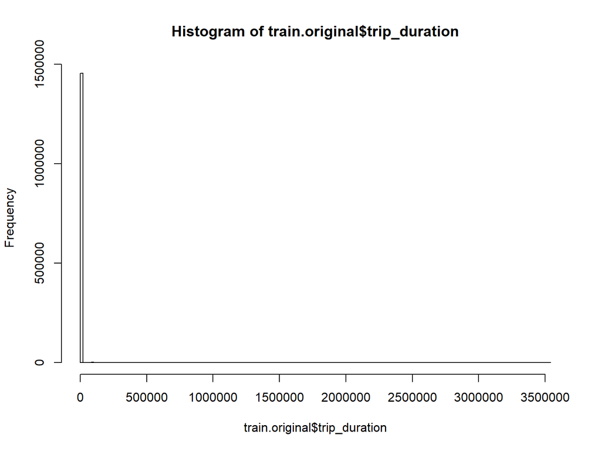

```r
hist(train.original$trip_duration,breaks=240)
```

Consideramos que viagens acima de 2 horas dentro da cidade indicam um erro e removemos esses itens da base de treino

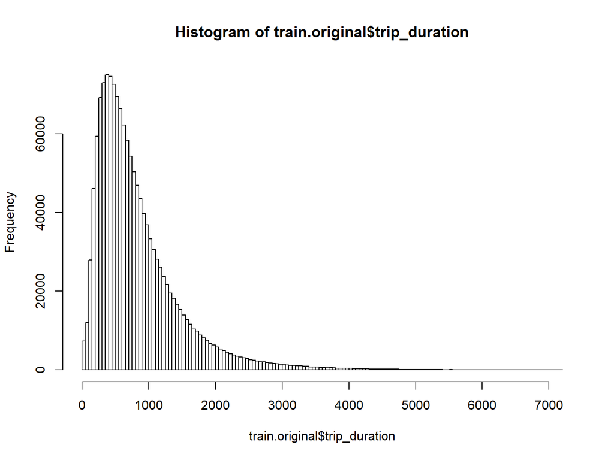

```r
train.original <- train.original[train.original$trip_duration<=60*60*2,]
hist(train.original$trip_duration, breaks = 240)
```

### Distância entre coordenadas

Recebemos a distância em coordenadas geográficas para corrigir a distância euclidiana entre os pontos definimos uma função que converte a diferença os graus para radianos e multiplica pelo raio da terra (de acordo com a fórmula de área de perimetro do circulo 2*r)

```r
# Converte graus para rads para usar as funções matemáticas
# (Cordenadas são em graus)
grausParaRadianos <- function(graus){
  graus * (pi/180)
}

#calcula distancia em graus e converte para metros
distanciaEuclidiana <- function(coords){
  lat1 <- coords[1]
  long1 <- coords[2]
  lat2 <- coords[3]
  long2 <- coords[4]
  x <- lat2 - lat1
  y <- long2 - long1
  h <- sqrt(x*x+y*y)
  r <- 6371000 #raio da terra em m
  rad <- grausParaRadianos(h)
  d<- rad*r
  d
}
```

### Distância de Manhattan 29º

Como estamos trabalhando especificamente com a cidade de Manhattan é mais preciso utilizar a distância de Manhattan do que a euclidiana,o único fator de dificuldade para essa operação é que a cidade de manhattan tem uma rotação de 29º em relação ao norte geográfico e por isso precisamos aplicar uma matriz de transformação nas coordenadas do mapa, no caso rotacionamos o destido em relação à origem da viagem:

[figure not shown]

Imagem do Google Maps

[figure not shown]

Imagem do Google Maps

```r
distanciaManhatan <- function(coords){
  lat1 <- coords[1]
  long1 <- coords[2]
  lat2 <- coords[3]
  long2 <- coords[4]
  d1 <- distanciaEuclidiana(c(lat1,0,lat2,0))
  d2 <- distanciaEuclidiana(c(0,long1,0,long2))
  d <- d1+d2
  d
}

# a cidade de manhatan tem uma inclinação de 29º em relação ao norte
rotacionaCoordenadas <- function(coords){
  lat1 <- coords[1]
  long1 <- coords[2]
  lat2 <- coords[3]
  long2 <- coords[4]
  x1 <- lat2 - lat1
  y1 <- long2 - long1
  angulo <- grausParaRadianos(29)
  x2 <- x1 * cos(angulo) - y1 * sin(angulo)
  y2 <- x1 * sin(angulo) + y1 * cos(angulo)

  x <- x2 + lat1
  y <- y2 + long1

  c(lat1,long1,x,y)
}

#calcula a distancia utilizando a distancida de manhattan com cordenadas rotacionas em 29º
distancia <- function(lat1, long1, lat2, long2){
  d <- rep(0,length(lat1))
  for(i in 1:length(lat1)){

    a <- c(lat1[i],long1[i],lat2[i],long2[i])

    d[i] <- rotacionaCoordenadas(a) %>% distanciaManhatan
  }
  d
}
```

### Estimativa de trânsito

Como não temos uma fonte de dados que indique o trânsito, estimamos um fator de transito de acordo com o horário pela distribuição dos embarques:

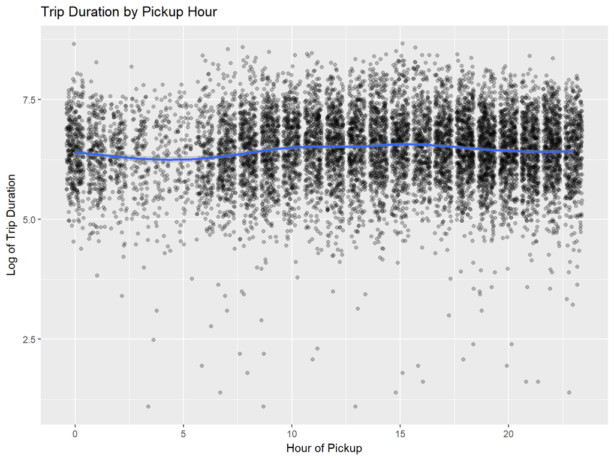

```r
#plot feito com um sample por questão de melhor visualização e tempo de processamento
sample <- train.original %>% mutate(pickup_hour = hour(ymd_hms(pickup_datetime))) %>% sample_n(10000)
ggplot(sample, aes(x = pickup_hour, y = log(trip_duration))) + geom_point(position = "jitter", alpha = 0.25) + geom_smooth() +labs(x = "Hour of Pickup", y = "Log of Trip Duration", title = "Trip Duration by Pickup Hour")
```

Realizamos uma agregação particionando por hora para termos uma variável que represente uma escala do volume esperado de embarques no periodo e assim podemos identificar os horários de alta e baixa demanda:

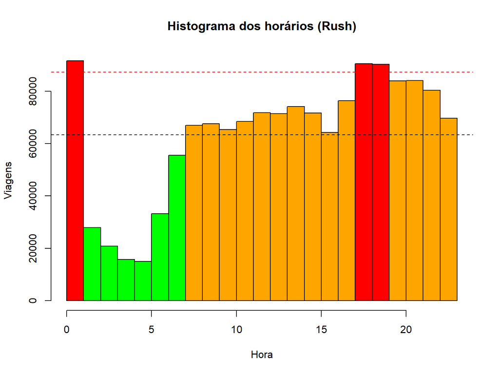

```r
#analisa horários de pico
rush <- hour(train.original$pickup_datetime)
rush.hist <- hist(rush,  breaks = 23, plot = FALSE)
rush.mean <- mean(rush.hist$counts) #media
rush.sd <- sd(rush.hist$counts) #desvio padrão
hcol <- rep('orange',24) #padrão laranja (transito moderado)
hcol[rush.hist$counts<rush.mean] <- 'green' #transito abaixo da média
hcol[rush.hist$counts>rush.mean+rush.sd] <- 'red' #transito Intenso (media + desvio padrão)
hist(rush,  breaks = 23, plot = TRUE, freq = TRUE,main = 'Histograma dos horários (Rush)', xlab = 'Hora', ylab='Viagens', col = hcol)
abline(rush.mean,0, lty=2)
abline(rush.mean+rush.sd,0, col='red', lty=2)
```

### Aplicando Transformações

Aplicamos as tranformações nos datasets e trocamos as coordenadas pela distância estimada e os horários pelo indicador de demanda de embarque:

```r
# Calculando distâncias, limpando dados e classificando horários de pico. Essa operação pode demorar alguns minutos

train <- transmute(train.original, id, vendor_id, passenger_count, recording=store_and_fwd_flag=='Y',
       distance = distancia(pickup_latitude,pickup_longitude,dropoff_latitude, dropoff_longitude),
       traffic=ifelse(is.na(pickup_datetime),rush.mean,rush.hist$counts[hour(pickup_datetime)]) , trip_duration)

# Fazendo o mesmo para a base de teste

test <- transmute(test.original, id, vendor_id, passenger_count, recording=store_and_fwd_flag=='Y',
                  distance = distancia(pickup_latitude,pickup_longitude,dropoff_latitude, dropoff_longitude),
                  traffic=ifelse(is.na(pickup_datetime),rush.mean,rush.hist$counts[hour(pickup_datetime)]))

head(train)
```

```
## # A tibble: 6 × 7
##          id vendor_id passenger_count recording distance traffic
##       <chr>     <int>           <int>     <lgl>    <dbl>   <int>
## 1 id2875421         2               1     FALSE 2750.258   76372
## 2 id2377394         1               1     FALSE 2560.756   68392
## 3 id3858529         2               1     FALSE 9280.607   90193
## 4 id3504673         2               1     FALSE 2099.796   71340
## 5 id2181028         2               1     FALSE 1610.112   80343
## 6 id0801584         2               6     FALSE 1697.223   80343
## # ... with 1 more variables: trip_duration <int>
```

### Limpeza de outliers

Similar ao problema da duração de viagem temos um problema com distância muito grandes:

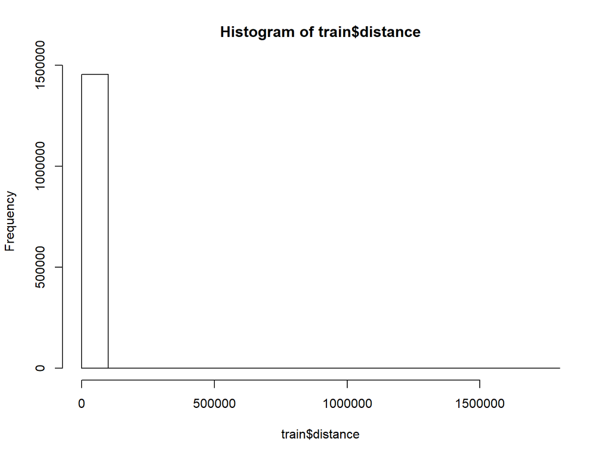

```r
hist(train$distance)
```

Removemos distâncias muito maiores do que o esperado utilizando a distância interquartil com fator 1.5:

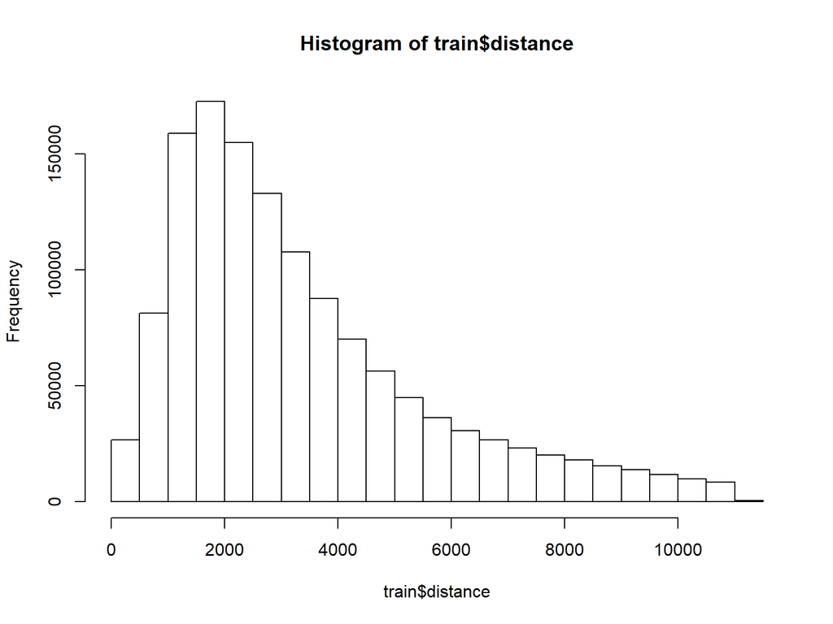

```r
qnt <- quantile(train$distance, probs=c(.25, .75))
H <- 1.5 * IQR(train$distance)
dist <- train$distance
train<- train[dist <= (qnt[2] + H),]

hist(train$distance)
```

# Desenvolvimento de modelos

Para a resolução do problema utilizamos 2 modelos diferentes apresentados aqui por ordem de efetividade.

## KMeans

Antes de aplicar os modelos, utilizamos o Kmeans como ferramenta de análise exploratória, para entender melhor a distribuição dos dados.

```r
#para reproducibilidade
set.seed(20)

#cria o cluster
NYCTripCluster <- kmeans(train.original[, c(2,5)], 2, nstart = 20)

#Criando a tabela para visualizar o resultado do Cluster com Kmeans

base::table(NYCTripCluster$cluster,train.original$store_and_fwd_flag)
```

```
##
##           N       Y
##   1  154216     187
##   2 1294133    7855
```

## Random Forest

Obtivemos um bom resultado com Ntree = 100:

```r
#Criando um modelo com randomForest com ntree = 100
rf_trip_duration <- randomForest(trip_duration ~ vendor_id + passenger_count + recording + distance + traffic ,data = train,ntree = 100)

#fazendo a predição do modelo para trip_duration
rf_prediction <- predict(rf_trip_duration, test, type = "response")

#Preparando o arquivo de submissão em dataframe com a predição com id e trip_duration
submission_file <- data.frame(id = test$id, trip_duration = rf_prediction)

#Escrevendo o arquivo.csv para a submissão
write.csv(submission_file, "randomForest_tidy.csv", row.names=F)
```

após enviar o arquivo para testes no Kaggle obtivemos um erro quadrado médio de 0.67000

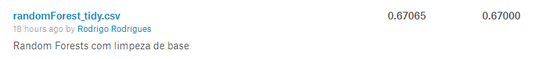

## Rede Neural

Utilizando uma rede neural obtivemos o melhor resultado entre os modelos, mas devido ao volume de dados não incluimos nesse arquivo o treinamento da rede completa, a execução desse código pode levar várias horas por isso realizamos com aproximadamente 1% dos dados:

```r
set.seed(500)
t<-train[,c(3,5,7)]
t <- t[sample(1:nrow(t),13000),]

model <- train(trip_duration ~  passenger_count + distance , t, method='nnet', linout=TRUE, trace = FALSE)
ps <- predict(model, test)

#Preparando o arquivo de submissão em dataframe com a predição com id e trip_duration

submission_file <- data.frame(id = test$id, trip_duration = ps)

#Escrevendo o arquivo.csv para a submissão

write.csv(submission_file, "randomNeuralNetsCaretSample.csv", row.names=F)
```

Com esse volume de dados obtivemos a acurácia de 0.59

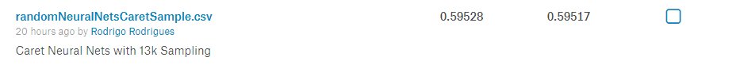

Resultado no Kaggle.com

Utilizando 10 % dos dados obtivemos a acurácia de 0.55

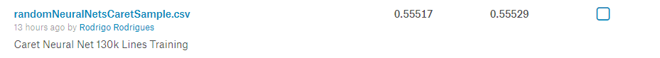

Resultado no Kaggle.com

# Conclusão

Concluímos através do desenvolvimento do presente trabalho, que é possível utilizar diferentes tecnologias para desenvolver um modelo preditivo, dentre as quais, utilizamos o Kmeans para classificação da gravação da viagem, Random Forest e Neural Networks para responder o desafio proposto no Kaggle e verificar a melhor estimativa para a duraçao da viagem de taxi. Acreditamos que há margem para melhorias pois as bses utilizadas necessitam de limpeza adicional, visto que a que por nós foi executa gerou um resultado de erro médio quadrado que pode ser influenciado por outros tipos de parâmetros e montagem de outros modelos que levariam a uma melhor acertividade.

# Crux

As dificuldades enfrentadas se deram em relação ao tamanho das bases de treino e teste originais, a realização da limpeza dos dados para tentar melhorar a análise, quais bibliotecas importar e saber quais os melhores modelos para solucionar o problema proposto. Sabemos que não existe um modelo padrão ou bala de prata, sendo a análise preditiva e a mineração de dados uma questão de arte, tecnologia e estratégia.